# Assignment 2

Karol Ciepły

14 grudnia 2022

## Exercise 1

### A.

```r
d_density <-
  c(5.5,5.61,4.88,5.07,5.26,5.55,5.36,5.29,5.58,5.65,5.57,5.53,5.62,5.29,5.44,5.34,5.79,5.1,5.27,5.39,5.42,5.47,5.63,5.34,5.46,5.3,5.75,5.68,5.85)

  density_mean <- mean(d_density)
  rounded <- round(density_mean, digits = 3)

  rounded
```

```
## [1] 5.448
```

### B.

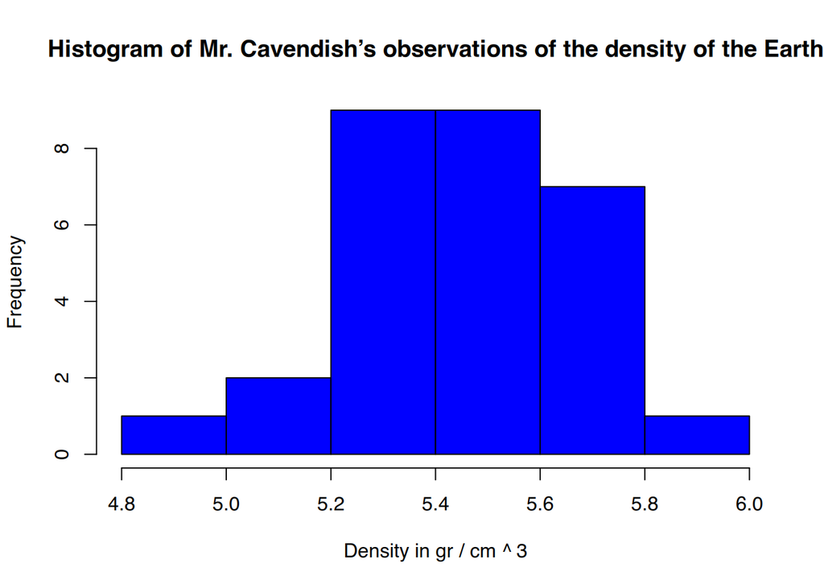

```r
hist(d_density, main = "Histogram of Mr. Cavendish’s observations of the density of the Earth",xlab = "Density in gr / cm ^ 3", col='blue')
```

### C.

We will use t-test to perform hypothesis testing because population variance is unknown to us

### D.

```r
t.test(d_density, mu = 5.1)
```

```
##
##  One Sample t-test
##
## data:  d_density
## t = 8.4802, df = 28, p-value = 3.205e-09
## alternative hypothesis: true mean is not equal to 5.1
## 95 percent confidence interval:
##  5.363888 5.531974
## sample estimates:
## mean of x
##  5.447931
```

The confidence interval is:
$$(5.363888,
5.531974)$$
The p-value is smaller than 0.05 so we reject the null hypothesis and there is evidence to support the alternative hypothesis, based on our data.

### E.

```r
t.test(d_density, mu = 5.5, alternative = "less")
```

```
##
##  One Sample t-test
##
## data:  d_density
## t = -1.2691, df = 28, p-value = 0.1074
## alternative hypothesis: true mean is less than 5.5
## 95 percent confidence interval:
##      -Inf 5.517726
## sample estimates:
## mean of x
##  5.447931
```

The confidence interval is:
$$(-\infty,
5.517726)$$
The p-value is larger than 0.05, so we fail to reject null hypothesis and there is not enough evidence to support alternative hypothesis, based on our data.

## Exercise 2

```r
t.test(iris$Sepal.Width ~ iris$Species, subset = iris$Species%in%c("virginica","versicolor"))
```

```
##
##  Welch Two Sample t-test
##
## data:  iris$Sepal.Width by iris$Species
## t = -3.2058, df = 97.927, p-value = 0.001819
## alternative hypothesis: true difference in means between group versicolor and group virginica is not equal to 0
## 95 percent confidence interval:
##  -0.33028364 -0.07771636
## sample estimates:
## mean in group versicolor  mean in group virginica
##                    2.770                    2.974
```

The confidence interval is
$$(-0.33028364, -0.07771636)$$
Null hypothesis is “true difference in means between group versicolor and group virginica is equal to 0”
Alternative hypothesis is “true difference in means between group versicolor and group virginica is not equal to 0”
The p-value is smaller than 0.05 so we reject the null hypothesis and there is evidence to support the alternative hypothesis, based on our data.

## Exercise 3

```r
df_iris <- iris
model <- lm(Petal.Width ~ Petal.Length, data = df_iris)
summary(model)
```

```
##
## Call:
## lm(formula = Petal.Width ~ Petal.Length, data = df_iris)
##
## Residuals:
##      Min       1Q   Median       3Q      Max
## -0.56515 -0.12358 -0.01898  0.13288  0.64272
##
## Coefficients:
##               Estimate Std. Error t value Pr(>|t|)
## (Intercept)  -0.363076   0.039762  -9.131  4.7e-16 ***
## Petal.Length  0.415755   0.009582  43.387  < 2e-16 ***
## ---
## Signif. codes:  0 '***' 0.001 '**' 0.01 '*' 0.05 '.' 0.1 ' ' 1
##
## Residual standard error: 0.2065 on 148 degrees of freedom
## Multiple R-squared:  0.9271, Adjusted R-squared:  0.9266
## F-statistic:  1882 on 1 and 148 DF,  p-value: < 2.2e-16
```

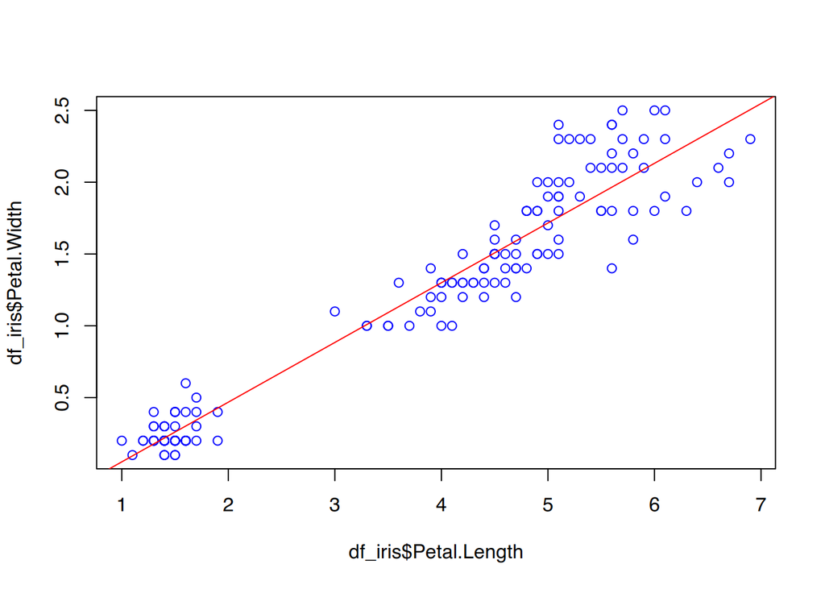

```r
plot(x = df_iris$Petal.Length, y = df_iris$Petal.Width, col='blue')
abline(model, col='red')
```

The $R^2 = 0.9271$ so this linear model fits the data well.

## Exercise 4

### A.

$$\begin{align*}
\text{We can derive the expression as such:} \\
P(m \le \frac{(n-1)S^2}{\sigma^2} &\le M) = 1 - \alpha \\
m \le \frac{(n-1)S^2}{\sigma^2} &\le M \\
\frac{1}{m} \ge \frac{\sigma^2}{(n-1)S^2} &\ge \frac{1}{M} \\
\frac{(n-1)S^2}{M} \le \sigma^2 &\le \frac{(n-1)S^2}{m} \\
\\
\text{The confidence interval for $ \sigma $ is the square root of the
above} \\
\sqrt{\frac{(n-1)S^2}{M}} \le \sigma &\le \sqrt{\frac{(n-1)S^2}{m}}
\end{align*}$$

### B.

```r
omnivores <-
  c(0.78, 0.80, 0.76, 0.78, 0.58, 0.64, 0.92, 0.86, 0.62, 0.54, 0.46)

vegetarians <-
  c(0.50,0.32,0.78,0.68,0.46,0.32,0.50,0.68,0.32,0.86,0.40,0.36,0.44,0.62,0.26)

alpha <- 0.05

len_o <- length(omnivores)
d_freedom_o <- len_o - 1

M_o <- qchisq(1 - alpha / 2, d_freedom_o)
m_o <- qchisq(alpha / 2, d_freedom_o)

L_o <- (d_freedom_o*var(omnivores)^2) / M_o
U_o <- (d_freedom_o*var(omnivores)^2) / m_o

L_o
```

```
## [1] 0.0002109219
```

```r
U_o
```

```
## [1] 0.001330578
```

```r
len_v <- length(vegetarians)
d_freedom_v <- len_v - 1

M_v <- qchisq(1 - alpha / 2, d_freedom_v)
m_v <- qchisq(alpha / 2, d_freedom_v)

L_v <- (d_freedom_v*var(vegetarians)^2) / M_v
U_v <- (d_freedom_v*var(vegetarians)^2) / m_v

L_v
```

```
## [1] 0.0006217113
```

```r
U_v
```

```
## [1] 0.002884924
```

The confidence interval for vegetarians for the variance $\sigma^2$ equals $(0.0006217113, 0.002884924)$

```r
Lstd_o <- sqrt(L_o)
Ustd_o <- sqrt(U_o)

Lstd_o
```

```
## [1] 0.01452315
```

```r
Ustd_o
```

```
## [1] 0.03647709
```

The confidence interval for omnivores for the standard deviation $\sigma$ equals $(0.01452315, 0.03647709)$

```r
Lstd_v <- sqrt(L_v)
Ustd_v <- sqrt(U_v)

Lstd_v
```

```
## [1] 0.02493414
```

```r
Ustd_v
```

```
## [1] 0.05371149
```

The confidence interval for vegetarians for the standard deviation $\sigma$ equals $(0.02493414, 0.05371149)$